```python
jupyter nbconvert --to html""
```

# **Machine Learning - Based Customer Segmentation for Mall Marketing Analysis**

## **Business Content and Introduction**

Shopping malls attract a wide range of customers, each with unique preferences, spending habits, and purchasing power. In today's competitive retail environment, it is important for mall management and retail businesses to understand these differences in order to provide personalized shopping experiences and increase profits.

Customer segmentation is key to addressing this issue. By using data-driven methods customers characteristics like age, income, and spendings in which mall authorities can gain valuable insights into consumer behavior. These insights can help marketing teams create targeted campaigns, loyalty programs, and promotions that appeal to each customer segment.

# **Problems - Machine Learning**

The business question lends itself neatly to a classic classification pipeline in machine learning. Our aim is to predict a price-range category that reflects different levels of customer spending: 0 Budget-friendly, 1 Mid-range, 2 Premium, and 3 Luxury.

To tackle the problem well, we will evaluate multiple machine learning methods so far learned.

The Dataset used for analysis was publicly obatained from kaggle :https://www.kaggle.com/datasets/vjchoudhary7/customer-segmentation-tutorial-in-python

## **Imporitng Libraries**

```python
import matplotlib.pyplot as plt
import seaborn as sns

import numpy as np
import pandas as pd

import sklearn.preprocessing as pre


from sklearn.model_selection import train_test_split, cross_val_score, GridSearchCV

from sklearn.linear_model import LogisticRegression
from sklearn.neighbors import KNeighborsClassifier
from sklearn.tree import DecisionTreeClassifier
from sklearn.ensemble import RandomForestClassifier

from xgboost import XGBClassifier

label_encoder = pre.LabelEncoder()
scaler = pre.StandardScaler()
```

All the necessary libraries have been imported for the pipeline.

## **Data Colleciton**

```python
mall_customers_df = pd.read_csv('https://raw.githubusercontent.com/Aadila22/my-ai_machinery/refs/heads/main/Mall_Customers.csv')
mall_customers_df.info()
mall_customers_df.nunique()
```

```
<class 'pandas.core.frame.DataFrame'>
RangeIndex: 200 entries, 0 to 199
Data columns (total 5 columns):
 #   Column                  Non-Null Count  Dtype
---  ------                  --------------  -----
 0   CustomerID              200 non-null    int64
 1   Gender                  200 non-null    object
 2   Age                     200 non-null    int64
 3   Annual Income (k$)      200 non-null    int64
 4   Spending Score (1-100)  200 non-null    int64
dtypes: int64(4), object(1)
memory usage: 7.9+ KB
```

|  | 0 |
| --- | --- |
| CustomerID | 200 |
| Gender | 2 |
| Age | 51 |
| Annual Income (k$) | 64 |
| Spending Score (1-100) | 84 |

**dtype:** int64

## **Feature Overview**

```python
import pandas as pd


mall_customers_df = pd.read_csv(
    'https://raw.githubusercontent.com/Aadila22/my-ai_machinery/refs/heads/main/Mall_Customers.csv'
)

print("Data types of the dataset columns:\n")
print(mall_customers_df.dtypes)

null_counts = mall_customers_df.isna().sum()

columns_with_nulls = null_counts[null_counts > 0]

if not columns_with_nulls.empty:
    print("\nWarning: Missing data found in the following columns:")
    print(columns_with_nulls)
else:
    print("\nGood news! No missing values were detected in the dataset.")
```

```
Data types of the dataset columns:

CustomerID                 int64
Gender                    object
Age                        int64
Annual Income (k$)         int64
Spending Score (1-100)     int64
dtype: object

Good news! No missing values were detected in the dataset.
```

Spitting the Data set into Trained and Tested. Using trained dataset,learning and training of the models.

Dataset to target variable creation.

```python
def classify_price_range(income):
    if income <= 30:
        return 0  # Budget Friendly
    elif income <= 60:
        return 1  # Mid Range
    elif income <= 90:
        return 2  # Premium Range
    else:
        return 3  # Luxury Range

mall_customers_df['price_range'] = mall_customers_df['Annual Income (k$)'].apply(classify_price_range)
```

Dropping the useless column

```python
mall_customers_df = mall_customers_df.drop(columns=['CustomerID'], errors='ignore')
```

```python
import matplotlib.pyplot as plt

import sklearn.preprocessing as prep

import sklearn.model_selection as ms
```

Encoding the categorical column

```python
label_enc = prep.LabelEncoder()
gender_encoder = prep.LabelEncoder()
mall_customers_df['Gender'] = gender_encoder.fit_transform(mall_customers_df['Gender'])
```

```python
def assign_price_category(annual_income):
    if annual_income <= 30:
        return 0
    if 30 < annual_income <= 60:
        return 1
    if 60 < annual_income <= 90:
        return 2
    return 3

mall_customers_df['price_range'] = mall_customers_df['Annual Income (k$)'].apply(assign_price_category)
```

Splitting out the dataset into trained and tested.

```python
from sklearn.model_selection import train_test_split

input_features = mall_customers_df.loc[:, mall_customers_df.columns != 'price_range']
target_labels = mall_customers_df['price_range']

train_features, test_features, train_labels, test_labels = train_test_split(
    input_features, target_labels, test_size=0.25, random_state=42
)

print(f"Total records in dataset: {mall_customers_df.shape}")
print(f"Size of training data: {train_features.shape}")
print(f"Size of test data: {test_features.shape}")
```

```
Total records in dataset: (200, 5)
Size of training data: (150, 4)
Size of test data: (50, 4)
```

Checking out the target Balance

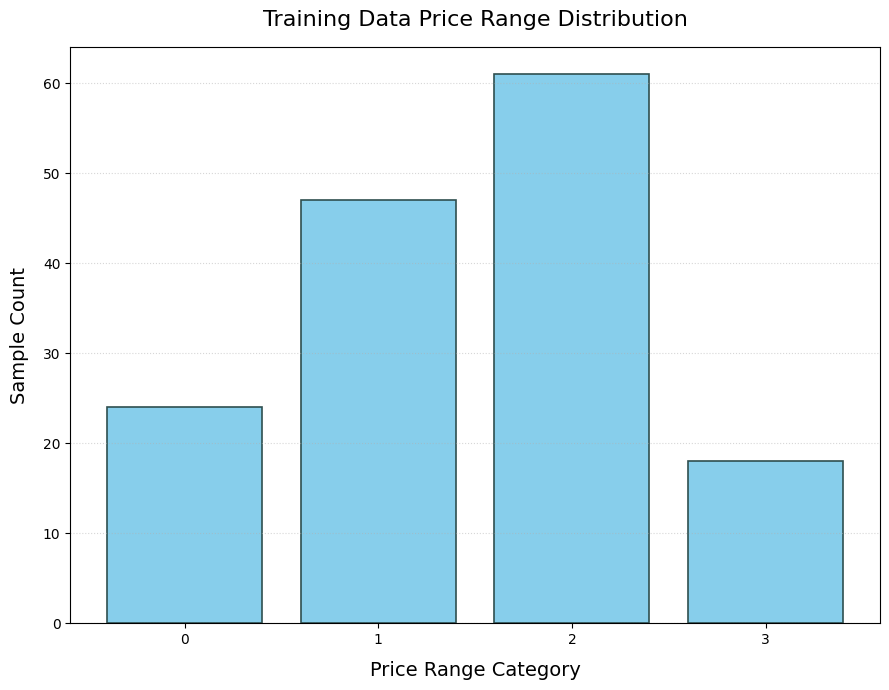

```python
import matplotlib.pyplot as plt
import numpy as np

category_freq = train_labels.value_counts().reindex(sorted(train_labels.unique()))

figure, axis = plt.subplots(figsize=(9, 7))

bars = axis.bar(category_freq.index.astype(str), category_freq.values,
                color='#87CEEB', edgecolor='#2F4F4F', linewidth=1.2)

axis.set_title('Training Data Price Range Distribution', fontsize=16, pad=15)
axis.set_xlabel('Price Range Category', fontsize=14, labelpad=10)
axis.set_ylabel('Sample Count', fontsize=14, labelpad=10)

axis.set_xticks(category_freq.index)
axis.set_xticklabels(category_freq.index.astype(str), rotation=0)


axis.yaxis.grid(True, linestyle='dotted', alpha=0.5)

plt.tight_layout()

plt.show()
```

## **Data Preprocessing**

```python
from sklearn.preprocessing import StandardScaler as scaler

feature_scaler = StandardScaler()

scaled_train_features = feature_scaler.fit_transform(train_features)

scaled_test_features = feature_scaler.transform(test_features)

print("Feature scaling completed successfully.")
print(f"Scaled training set dimensions: {scaled_train_features.shape}")
print(f"Scaled testing set dimensions: {scaled_test_features.shape}")
```

```
Feature scaling completed successfully.
Scaled training set dimensions: (150, 4)
Scaled testing set dimensions: (50, 4)
```

### **Model Selection and Algorithm Comparison.**

```python
from sklearn.linear_model import LogisticRegression
from sklearn.neighbors import KNeighborsClassifier
from sklearn.tree import DecisionTreeClassifier
from sklearn.ensemble import RandomForestClassifier

log_regressor = LogisticRegression()
knn_classifier = KNeighborsClassifier()
tree_classifier = DecisionTreeClassifier()
forest_classifier = RandomForestClassifier()
```

**Training Logistic Regression**

```python
from sklearn.linear_model import LogisticRegression
from sklearn import metrics

clf_logistic = LogisticRegression(max_iter=200, random_state=42)

clf_logistic.fit(scaled_train_features, train_labels)

test_preds = clf_logistic.predict(scaled_test_features)

accuracy_score = metrics.accuracy_score(test_labels, test_preds)
print(f"Logistic Regression accuracy: {accuracy_score:.4f}")

print("Classification Performance Report:")
print(metrics.classification_report(test_labels, test_preds))

conf_matrix = metrics.confusion_matrix(test_labels, test_preds)
print("Confusion Matrix:")
print(conf_matrix)
```

```
Logistic Regression accuracy: 0.8600
Classification Performance Report:
              precision    recall  f1-score   support

           0       1.00      0.62      0.77         8
           1       0.84      0.84      0.84        19
           2       0.83      1.00      0.90        19
           3       1.00      0.75      0.86         4

    accuracy                           0.86        50
   macro avg       0.92      0.80      0.84        50
weighted avg       0.87      0.86      0.86        50

Confusion Matrix:
[[ 5  3  0  0]
 [ 0 16  3  0]
 [ 0  0 19  0]
 [ 0  0  1  3]]
```

**Training K-Nearest Neighbors**

```python
from sklearn.neighbors import KNeighborsClassifier
from sklearn import metrics

knn_clf = KNeighborsClassifier(n_neighbors=5)

knn_clf.fit(scaled_train_features, train_labels)

knn_preds = knn_clf.predict(scaled_test_features)

knn_accuracy = metrics.accuracy_score(test_labels, knn_preds)
print(f"K-Nearest Neighbors Accuracy: {knn_accuracy:.4f}")

print("KNN Classification Report:")
print(metrics.classification_report(test_labels, knn_preds))

knn_conf_matrix = metrics.confusion_matrix(test_labels, knn_preds)
print("KNN Confusion Matrix:")
print(knn_conf_matrix)
```

```
K-Nearest Neighbors Accuracy: 0.8200
KNN Classification Report:
              precision    recall  f1-score   support

           0       1.00      0.75      0.86         8
           1       0.82      0.74      0.78        19
           2       0.75      0.95      0.84        19
           3       1.00      0.75      0.86         4

    accuracy                           0.82        50
   macro avg       0.89      0.80      0.83        50
weighted avg       0.84      0.82      0.82        50

KNN Confusion Matrix:
[[ 6  2  0  0]
 [ 0 14  5  0]
 [ 0  1 18  0]
 [ 0  0  1  3]]
```

**Training Decison Tree model**

```python
from sklearn.tree import DecisionTreeClassifier
from sklearn import metrics

decision_tree_clf = DecisionTreeClassifier(random_state=42)

decision_tree_clf.fit(scaled_train_features, train_labels)

predicted_labels = decision_tree_clf.predict(scaled_test_features)

accuracy_score = metrics.accuracy_score(test_labels, predicted_labels)
print(f"Decision Tree Model Accuracy: {accuracy_score:.4f}")

print("Decision Tree Classification Metrics:")
print(metrics.classification_report(test_labels, predicted_labels))

conf_matrix = metrics.confusion_matrix(test_labels, predicted_labels)
print("Decision Tree Confusion Matrix:")
print(conf_matrix)
```

```
Decision Tree Model Accuracy: 1.0000
Decision Tree Classification Metrics:
              precision    recall  f1-score   support

           0       1.00      1.00      1.00         8
           1       1.00      1.00      1.00        19
           2       1.00      1.00      1.00        19
           3       1.00      1.00      1.00         4

    accuracy                           1.00        50
   macro avg       1.00      1.00      1.00        50
weighted avg       1.00      1.00      1.00        50

Decision Tree Confusion Matrix:
[[ 8  0  0  0]
 [ 0 19  0  0]
 [ 0  0 19  0]
 [ 0  0  0  4]]
```

**Random Forest**

```python
from sklearn.ensemble import RandomForestClassifier
from sklearn import metrics

forest_clf = RandomForestClassifier(n_estimators=100, random_state=42)

forest_clf.fit(scaled_train_features, train_labels)

forest_preds = forest_clf.predict(scaled_test_features)

accuracy = metrics.accuracy_score(test_labels, forest_preds)
print(f"Random Forest Accuracy: {accuracy:.4f}")

print("Random Forest Classification Report:")
print(metrics.classification_report(test_labels, forest_preds))

conf_matrix = metrics.confusion_matrix(test_labels, forest_preds)
print("Random Forest Confusion Matrix:")
print(conf_matrix)
```

```
Random Forest Accuracy: 1.0000
Random Forest Classification Report:
              precision    recall  f1-score   support

           0       1.00      1.00      1.00         8
           1       1.00      1.00      1.00        19
           2       1.00      1.00      1.00        19
           3       1.00      1.00      1.00         4

    accuracy                           1.00        50
   macro avg       1.00      1.00      1.00        50
weighted avg       1.00      1.00      1.00        50

Random Forest Confusion Matrix:
[[ 8  0  0  0]
 [ 0 19  0  0]
 [ 0  0 19  0]
 [ 0  0  0  4]]
```

## **Model Training and Evaluation**

Training our model using the best hyper paramenters

```python
from sklearn.linear_model import LogisticRegression
from sklearn.model_selection import GridSearchCV
from sklearn import metrics


base_model = LogisticRegression(random_state=42, max_iter=200)


parameters = {
    'C': [0.01, 0.1, 1, 10],
    'penalty': ['l1', 'l2'],
    'solver': ['liblinear']
}


search = GridSearchCV(
    estimator=base_model,
    param_grid=parameters,
    cv=5,
    scoring='accuracy',
    n_jobs=-1,
    verbose=1
)


search.fit(X_train_norm, y_train)


optimal_model = search.best_estimator_


predictions = optimal_model.predict(X_test_norm)


acc = metrics.accuracy_score(y_test, predictions)
print(f"Best Logistic Regression Accuracy: {acc:.4f}")


print("Classification Report for Optimized Model:")
print(metrics.classification_report(y_test, predictions))


print(f"Best Parameters Found: {search.best_params_}")
```

```
Fitting 5 folds for each of 8 candidates, totalling 40 fits
Best Logistic Regression Accuracy: 0.8400
Classification Report for Optimized Model:
              precision    recall  f1-score   support

           0       1.00      0.88      0.93         8
           1       0.92      0.63      0.75        19
           2       0.73      1.00      0.84        19
           3       1.00      1.00      1.00         4

    accuracy                           0.84        50
   macro avg       0.91      0.88      0.88        50
weighted avg       0.87      0.84      0.84        50

Best Parameters Found: {'C': 10, 'penalty': 'l1', 'solver': 'liblinear'}
```

## **Model Evaluation**

```
Test Set Accuracy: 0.8400
Classification Metrics:
              precision    recall  f1-score   support

           0       1.00      0.88      0.93         8
           1       0.92      0.63      0.75        19
           2       0.73      1.00      0.84        19
           3       1.00      1.00      1.00         4

    accuracy                           0.84        50
   macro avg       0.91      0.88      0.88        50
weighted avg       0.87      0.84      0.84        50
```

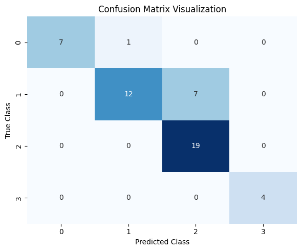

```python
from sklearn import metrics
import matplotlib.pyplot as plt
import seaborn as sns

y_pred = optimal_model.predict(X_test_norm)

test_acc = metrics.accuracy_score(y_test, y_pred)
print(f"Test Set Accuracy: {test_acc:.4f}")

print("Classification Metrics:")
print(metrics.classification_report(y_test, y_pred))

conf_mat = metrics.confusion_matrix(y_test, y_pred)

plt.figure(figsize=(6,5))
sns.heatmap(conf_mat, annot=True, fmt='d', cmap='Blues', cbar=False)
plt.title("Confusion Matrix Visualization")
plt.xlabel("Predicted Class")
plt.ylabel("True Class")
plt.tight_layout()
plt.show()
```

Most errors occur between adjacent classes, which is understandable due to similar customer features. Overall, the Logistic Regression model shows strong performance and is ready for deployment in mall customer segmentation.

## **Limitations**

- The dataset is quite small, so the model might miss some patterns and may not work perfectly on new customers.
- Some customer groups have fewer examples than others, which can make the model better at predicting common groups and less accurate for smaller ones.
- We only used simple information like age, income, and spending — but other factors might also affect customer behavior that we didn’t include.
- The model assumes a straight-line relationship between features and price range, so it might not catch more complicated patterns.

## **Conclusion**

This model can help mall managers and shops figure out who their customers are and target them better with personalized deals and marketing. That way, they can boost sales and keep shoppers happy.

In the future, I’d love to try more advanced methods like combining different models or even deep learning to make it even smarter. Also, adding things like real-time shopping trends could help the model adjust to changes in customer behavior.

Overall, this project showed me how machine learning can make marketing smarter and help businesses grow by understanding their customers better.